# Introduction to Bayesian inference using a disease prevalence example

In this exercise, we invite participants to use Bayesian inference to estimate the prevalence of a disease.

## Aim

Suppose we collect data $X = 4$ individuals testing positive for a disease in a sample of size $N = 10$. Our aim is to estimate the disease prevalence, $\theta$, in the population the individuals were sampled from.

## Determining an appropriate probability distribution

1. Why would you not use a normal distribution to represent the model which generated the data?

The data are discrete, not continuous.

2. Why would you not use a Poisson distribution?

The data have an upper bound of $N$.

3. Why might a binomial distribution be an appropriate probability distribution?

It may be if we assume the individuals were randomly sampled (i.e. independently and identically distributed).

4. Plot the binomial distribution with $N=10$ and show how it varies across $\theta = (0.1, 0.5, 0.9)$.

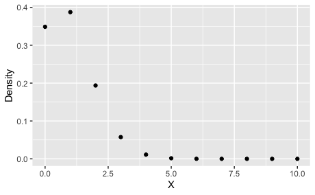

```r
rm(list=ls())
library(tidyverse)
library(reshape2)
N <- 10
theta <- 0.1
x_values <- seq(0, N, 1)
density_values <- map_dbl(x_values, ~dbinom(., N, theta))
qplot(x_values, density_values) +
  xlab("X") +
  ylab("Density")
```

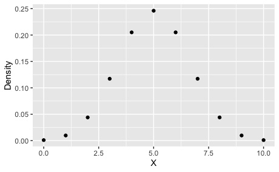

```r
theta <- 0.5
x_values <- seq(0, N, 1)
density_values <- map_dbl(x_values, ~dbinom(., N, theta))
qplot(x_values, density_values) +
  xlab("X") +
  ylab("Density")
```

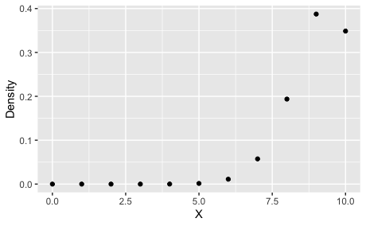

```r
theta <- 0.9
x_values <- seq(0, N, 1)
density_values <- map_dbl(x_values, ~dbinom(., N, theta))
qplot(x_values, density_values) +
  xlab("X") +
  ylab("Density")
```

## Maximum likelihood estimation

5. Plot the likelihood function.

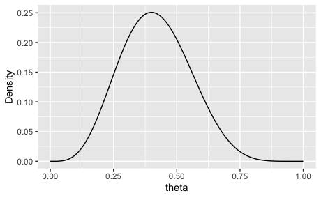

```r
X <- 4
N <- 10
theta <- seq(0, 1, length.out = 300)
likelihood_values <- map_dbl(theta, ~dbinom(X, N, .))
tibble(theta=theta, likelihood=likelihood_values) %>%
  ggplot(aes(theta, likelihood)) +
  geom_line() +
  xlab("theta") +
  ylab("Density")
```

6. What’s the maximum likelihood estimate of $\theta$?

There are two ways to handle this: one is mathematical and involves maximising the (log-)likelihood; the other just uses numerical search.

Mathematical. The likelihood is:

$L = {N \choose X} \theta^X (1-\theta)^{N-X}$

The log-likelihood is: $\log L \propto X \log \theta + (N - X) \log (1 -\theta)$

Now differentiate to find max likelihood estimator:

$\frac{d\log L}{d\theta} \propto \frac{X}{\theta} - \frac{N - X}{1-\theta} = 0$

Rearranging, we get: $\theta = \frac{X}{N} = \frac{4}{10}$, i.e. the proportion of disease-positive examples in our data.

The numerical way is as below.

```r
# optim works by minimising, so take -1 * likelihood
res <- optim(0.5, function(theta) -dbinom(X, N, theta))
```

```
one-dimensional optimization by Nelder-Mead is unreliable:
use "Brent" or optimize() directly
```

```r
res$par
```

```
[1] 0.4
```

## Bayesian estimation

7. Assume that based on a previous meta-analysis, we have a prior $\theta\sim \text{beta}(1, 4)$. Plot the numerator of Bayes’ rule: $p(\theta)\times p(X|\theta)$.

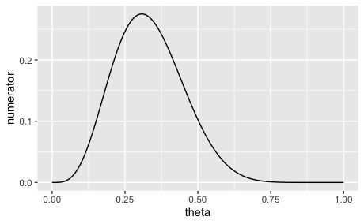

```r
likelihood <- function(theta) dbinom(X, N, theta)
prior <- function(theta) dbeta(theta, 1, 4)
numerator <- function(theta) likelihood(theta) * prior(theta)
numerator_values <- map_dbl(theta, ~numerator(.))
tibble(theta=theta, numerator=numerator_values) %>%
  ggplot(aes(x=theta, y=numerator)) +
  geom_line()
```

8. Determine the denominator of Bayes’ rule using numerical integration:
- in R, this can be done using the `integrate` function
- in Python, this can be done using `scipy.integrate.quad`

```r
p_data <- integrate(function(theta) numerator(theta), 0, 1)$value
p_data
```

```
[1] 0.08391608
```

9. Hence make a function that yields the posterior density.

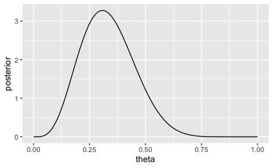

```r
posterior <- function(theta) numerator(theta) / p_data
posterior_values <- map_dbl(theta, ~posterior(.))
tibble(theta=theta, posterior=posterior_values) %>%
  ggplot(aes(x=theta, y=posterior)) +
  geom_line()
```

10. An alternative way to obtain the posterior distribution is to use conjugate prior rules. i.e. that if $\theta\sim \text{beta}(a, b)$ and $X|\theta\sim \mathcal{B}(N, \theta)$, then $\theta|X\sim \text{beta}(a + X, b + N - X)$. Use this relationship to investigate how the posterior changes holding $b=4$ and change from $a=1$ to $a=8$.

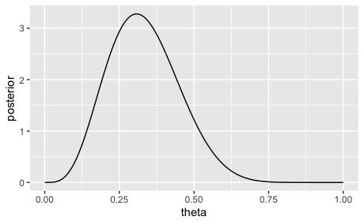

```r
posterior_conj <- function(theta, a) dbeta(theta, a + X, 4 + N - X)
a <- 1
posterior_values <- map_dbl(theta, ~posterior_conj(., a))
tibble(theta=theta, posterior=posterior_values) %>%
  ggplot(aes(x=theta, y=posterior)) +
  geom_line()
```

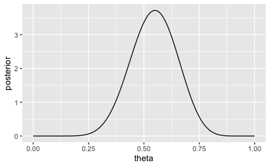

```r
a <- 8
posterior_values <- map_dbl(theta, ~posterior_conj(., a))
tibble(theta=theta, posterior=posterior_values) %>%
  ggplot(aes(x=theta, y=posterior)) +
  geom_line()
```

11. Calculate the posterior 10%-90% quantiles assuming $a=1$.

```r
a <- 1
b <- 4
lower <- qbeta(0.1, a + X, b + N - X)
upper <- qbeta(0.9, a + X, b + N - X)
c(lower, upper)
```

```
[1] 0.1851342 0.4919652
```

12. Forecast what data will be obtained in a second experiment, where $N=100$ assuming $a=1$. You can do this by sampling by iterating the following steps:
- $\theta_i \sim p(\theta|X)$, i.e. draw from the posterior distribution.
- $X_i \sim p(X|\theta_i)$, i.e. draw from the sampling distribution.

The distribution of $p(X)$ obtained via this process is known as the posterior predictive distribution. In your case, use 10,000 draws from this distribution then plot a histogram of the resultant draws.

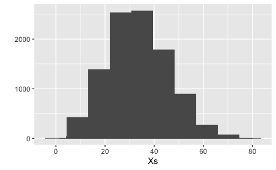

```r
n_draws <- 10000
Xs <- vector(length = n_draws)
for(i in 1:n_draws) {
  theta_i <- rbeta(1, a + X, b + N - X)
  Xs[i] <- rbinom(1, 100, theta_i)
}
qplot(Xs) +
  geom_histogram(bins=10)
```

13. Use your posterior predictive distribution to determine $Pr(X > 50)$ in a new experiment.

```r
mean(Xs > 50)
```

```
[1] 0.0988
```